# Paper: Solidarity and Performance Voting’

Heike Klüver, Humboldt

Felix Hartmann, Humboldt

Macartan Humphreys, WZB and Columbia

Ferdinand Geißler, Humboldt

Johannes Giesecke, Humboldt

Abstract

Respondents support high levels of cash and vaccine transfers to help poorer nations. They are more supportive when health and economic risks of failing to provide support are high; but for the most part support does not depend on these calculations. Preferences over German policy are largely independent of what other countries are doing. Median support for vaccines (90 million) and cash (2 billion) corresponds closely to actual (100 million doses and 2.2 billion cash).

# 1 Setup

```r
knitr::opts_chunk$set(echo=TRUE, warning=FALSE, message=FALSE, comment=NA)
options(qwraps2_markup = "markdown")

## Packages
if (!require(pacman)) install.packages("pacman")
```

```r
pacman::p_load(
  ggridges,    # plot
  cregg,       # conjoint
  readxl,      # read excel
  gtrendsR,    # google trends
  aod,         # hypothesis testing (1.3.1)
  car,         # linear hypothesis testing for causal tree (3.0-2)
  corrplot,    # Correlations (0.84)
  DeclareDesign,
  dplyr,       # Data manipulation (0.8.0.1)
  evtree,      # evolutionary learning of globally optimal trees (1.0-7)
  fastDummies,
  fBasics,     # Summary statistics (3042.89)
  ggplot2,
  grf,         # Generalized random forests (0.10.2)
  haven,       # load sav
  kableExtra,  # Prettier RMarkdown (1.0.1)
  knitr,
  labelled,
  psych,       # Correlation p-values (1.8.12)
  purrr,
  rpart,       # Classification and regression trees, or CART (4.1-13)
  reshape2,
  rpart.plot,  # Plotting trees (3.0.6)
  readr,       # Reading csv files (1.3.1)
  sjlabelled,
  stats,
  summarytools,
  texreg,
  tidyverse,
  tidyselect,
  tidyr,       # Database operations (0.8.3)
  treeClust,   # Predicting leaf position for causal trees (1.1-7)
  tibble)      # Modern alternative to data frames (2.1.1)


# Set seed for reproducibility
set.seed(201911)

# Paths
# datapath <- "../../../4_data/wave_2/D-P21-13185 HU Berlin Impfskeptiker_Welle 2_Testdatensatz.sav"


# First Wave: to get the covariates

firstwave <- "../../../4_data/wave_1/D-P21-13185 HU Berlin Impfskeptiker_Finaler_Datensatz.sav"


datapath <- "../../../4_data/wave_2/D-P21-13185 HU Berlin Impfskeptiker_Welle 2_Finaler_Datensatz.sav"

vignettepath <- "../../../4_data/wave_2/W2_exp3_vignettes_universe.dta"

# data from the 9th of September
fourthwave <- "1_input/D-P21-13185 HU Berlin Impfskeptiker_Welle 4_Finaler_Datensatz---Combined"

vignettepath_7 <- "1_input/W4_exp7_vignettes_universe_-_20210831.dta"


# variable names and labels
var_list_1<- read.csv("1_input/varsfirstwave.csv") %>% arrange(order)
var_list_2 <- read.csv("1_input/varssecondwave.csv") %>% arrange(order)

var_list<-rbind(var_list_1,var_list_2)

outcomes <- c("solidarity_bahaviour", "solidarity_attitude")
outcome_labels <- c("Solidarity Bahaviour", "Solidarity Attitude")
treatments <- c("treatment_video")
treatment_labels <- c("Treatment")
```

```r
covariate_names_1 <- var_list_1$new_name[var_list_1$covariate==1]
covariate_names_2 <- var_list_2$new_name[var_list_2$covariate==1]
```

## 1.1 Prep wave 2 data

```r
source("prep_w2.R")
```

```r
# w4 <- haven::read_dta(fourthwave)
w4 <- haven::read_sav(fourthwave)

labs <- var_label(w4) %>% unlist
# data.frame(names(labs), labs) %>% kable()

# View(w4)

vign_values <- read_dta("1_input/W4_exp8_vignettes_universe_-_20210825.dta")

df <-
  list(
    w4 %>%
      mutate(vignr = as.numeric(c_0037)) %>% left_join(vign_values) %>%
      mutate(round = 1,
         cash =     exp7_money1,
         doses = exp7_doses1) %>%
      select(group, lfdn, round, cash, doses, trading_importance, risk, deal, ID),

    w4 %>%
      mutate(vignr = as.numeric(c_0038)) %>% left_join(vign_values) %>%
      mutate(round = 2,
         cash =     exp7_money2,
         doses = exp7_doses2) %>%
      select(group, lfdn, round, cash, doses, trading_importance, risk, deal, ID)) %>%
  bind_rows %>%
  dplyr::filter(group !=3) %>%
  mutate(id = paste(lfdn, group),
         others_number = (deal==1 | deal == 3)*2 + (deal==2 | deal == 4)*4,
         others_giving = (deal==1 | deal == 2)*2 + (deal==3 | deal == 4)*4,
         others_average = others_giving/others_number,
         risk_factor = factor(risk, 0:1, c("Low", "High")),
         trading_factor = factor(trading_importance, 0:1, c("Low", "High")),
         risk = risk - mean(risk),
         trading_importance = trading_importance - mean(trading_importance),
         others_number = others_number - mean(others_number),
         others_giving =others_giving - mean(others_giving))

main_results <-
  list(
  cash = lm_robust(cash ~ trading_importance*risk*others_number*others_giving  + round, fixed_effects = ~id,  se_type = "stata", data = df) %>% tidy,
  doses = lm_robust(doses ~ trading_importance*risk*others_number*others_giving  + round, fixed_effects = ~id,  se_type = "stata", data = df) %>% tidy) %>% bind_rows()


 treatments <- c("trading_importance", "risk", "others_number", "others_giving")
 treatment_labels <- c("Trading importance", "Risk", "Number of others giving (10s)", "Amount given by others\n(10s of billions)")
```

# 2 Descriptives

The average proposal is: 8.67 billion Euros and 78 million doses.

The median proposal is: 2 billion Euros and 90 million doses.

These are close to actual https://www.auswaertiges-amt.de/en/aussenpolitik/themen/gesundheit/covax/2396914.

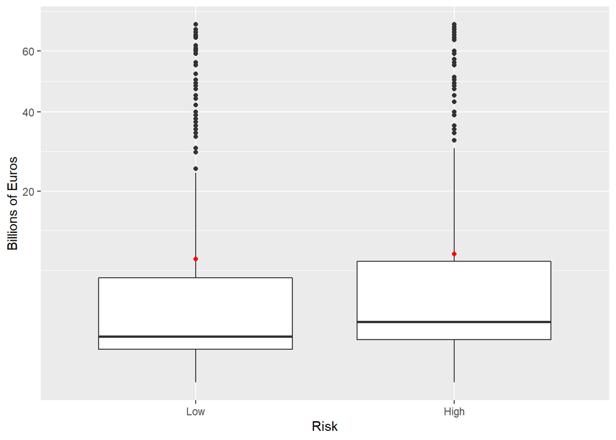

```r
figure_1 <-

  main_results %>%
  dplyr::filter(term %in% treatments) %>%
  mutate(Treatment = factor(term, treatments, treatment_labels)) %>%

  ggplot(aes(estimate, Treatment)) + geom_point()+
  geom_errorbar(aes(xmin = conf.low, xmax = conf.high), width = .1)+
  geom_vline(xintercept=0, linetype="longdash", lwd=0.35, colour = "#B55555") +
  theme_bw() + facet_grid(~outcome, scales = "free_x")+
  ylab("")


df_mean <- df %>%
  group_by(risk_factor) %>%
  summarize(average = mean(cash, na.rm = TRUE)) %>%
  ungroup()

figure_2 <-
  df %>%
  ggplot(aes(risk_factor, cash)) +
  geom_boxplot() + ylab("Billions of Euros")   + xlab("Risk")  + scale_y_sqrt() +
  geom_point(data = df_mean,
             mapping = aes(x = risk_factor, y = average),
             color="red")

figure_3 <-
  df %>%
  ggplot(aes(risk_factor, doses)) +
  geom_boxplot() + ylab("Millions of doses") + xlab("Risk")



figure_2
```

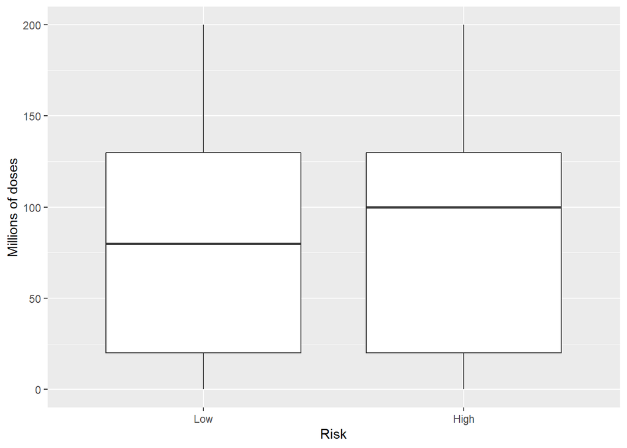

```r
figure_3
```

Note that the doses options was limited to between 0 and 200 m.

Offers are responsive to risk and economic impacts but not much to coordination cosiderations.

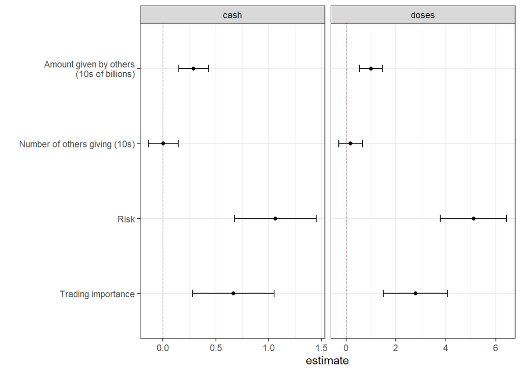

```r
figure_1
```

Trading importance and risk are substitutes for cash but not doses.

Without demeaning:

```r
lm_robust(cash ~ trading_factor*risk_factor+ round, fixed_effects = ~id,  se_type = "stata", data = df) %>% tidy  %>%
  kbl(digit =2) %>%
  kable_minimal()
```

| term | estimate | std.error | statistic | p.value | conf.low | conf.high | df | outcome |
| --- | --- | --- | --- | --- | --- | --- | --- | --- |
| trading_factorHigh | 0.83 | 0.23 | 3.54 | 0.00 | 0.37 | 1.29 | 10521 | cash |
| risk_factorHigh | 1.64 | 0.24 | 6.94 | 0.00 | 1.18 | 2.11 | 10521 | cash |
| round | 0.01 | 0.12 | 0.10 | 0.92 | -0.22 | 0.24 | 10521 | cash |
| trading_factorHigh:risk_factorHigh | -0.65 | 0.32 | -2.01 | 0.04 | -1.28 | -0.02 | 10521 | cash |

Logging helps and substitution not as strong:

```r
lm_robust(log(cash+1) ~ trading_factor*risk_factor+ round, fixed_effects = ~id,  se_type = "stata", data = df) %>% tidy  %>%
  kbl(digit =2) %>%
  kable_minimal()
```

| term | estimate | std.error | statistic | p.value | conf.low | conf.high | df | outcome |
| --- | --- | --- | --- | --- | --- | --- | --- | --- |
| trading_factorHigh | 0.10 | 0.01 | 6.76 | 0.00 | 0.07 | 0.13 | 10521 | log(cash + 1) |
| risk_factorHigh | 0.16 | 0.01 | 10.80 | 0.00 | 0.13 | 0.19 | 10521 | log(cash + 1) |
| round | 0.02 | 0.01 | 2.10 | 0.04 | 0.00 | 0.03 | 10521 | log(cash + 1) |
| trading_factorHigh:risk_factorHigh | -0.05 | 0.02 | -2.34 | 0.02 | -0.09 | -0.01 | 10521 | log(cash + 1) |

## 2.1 Full results from saturated models

```r
main_results %>%
  kbl(digit =2) %>%
  kable_minimal()
```

| term | estimate | std.error | statistic | p.value | conf.low | conf.high | df | outcome |
| --- | --- | --- | --- | --- | --- | --- | --- | --- |
| trading_importance | 0.67 | 0.20 | 3.38 | 0.00 | 0.28 | 1.05 | 10509 | cash |
| risk | 1.06 | 0.20 | 5.37 | 0.00 | 0.68 | 1.45 | 10509 | cash |
| others_number | 0.00 | 0.07 | 0.05 | 0.96 | -0.14 | 0.14 | 10509 | cash |
| others_giving | 0.29 | 0.07 | 4.01 | 0.00 | 0.15 | 0.43 | 10509 | cash |
| round | 0.02 | 0.12 | 0.17 | 0.86 | -0.21 | 0.25 | 10509 | cash |
| trading_importance:risk | -0.23 | 0.39 | -0.60 | 0.55 | -1.00 | 0.53 | 10509 | cash |
| trading_importance:others_number | 0.03 | 0.15 | 0.19 | 0.85 | -0.26 | 0.32 | 10509 | cash |
| risk:others_number | 0.05 | 0.14 | 0.35 | 0.73 | -0.23 | 0.33 | 10509 | cash |
| trading_importance:others_giving | -0.03 | 0.15 | -0.24 | 0.81 | -0.32 | 0.25 | 10509 | cash |
| risk:others_giving | -0.04 | 0.15 | -0.24 | 0.81 | -0.33 | 0.26 | 10509 | cash |
| others_number:others_giving | -0.02 | 0.04 | -0.43 | 0.67 | -0.11 | 0.07 | 10509 | cash |
| trading_importance:risk:others_number | -0.30 | 0.28 | -1.08 | 0.28 | -0.86 | 0.25 | 10509 | cash |
| trading_importance:risk:others_giving | -0.02 | 0.30 | -0.06 | 0.95 | -0.60 | 0.56 | 10509 | cash |
| trading_importance:others_number:others_giving | -0.12 | 0.08 | -1.38 | 0.17 | -0.28 | 0.05 | 10509 | cash |
| risk:others_number:others_giving | 0.17 | 0.09 | 2.04 | 0.04 | 0.01 | 0.34 | 10509 | cash |
| trading_importance:risk:others_number:others_giving | -0.29 | 0.17 | -1.68 | 0.09 | -0.62 | 0.05 | 10509 | cash |
| trading_importance | 2.78 | 0.66 | 4.24 | 0.00 | 1.50 | 4.07 | 10509 | doses |
| risk | 5.11 | 0.68 | 7.52 | 0.00 | 3.78 | 6.44 | 10509 | doses |
| others_number | 0.18 | 0.24 | 0.76 | 0.45 | -0.29 | 0.65 | 10509 | doses |
| others_giving | 1.00 | 0.24 | 4.22 | 0.00 | 0.53 | 1.46 | 10509 | doses |
| round | 1.80 | 0.38 | 4.72 | 0.00 | 1.05 | 2.55 | 10509 | doses |
| trading_importance:risk | -0.67 | 1.24 | -0.54 | 0.59 | -3.10 | 1.76 | 10509 | doses |
| trading_importance:others_number | 0.30 | 0.48 | 0.63 | 0.53 | -0.64 | 1.24 | 10509 | doses |
| risk:others_number | 0.48 | 0.48 | 1.02 | 0.31 | -0.45 | 1.42 | 10509 | doses |
| trading_importance:others_giving | 0.01 | 0.47 | 0.02 | 0.99 | -0.92 | 0.93 | 10509 | doses |
| risk:others_giving | -0.58 | 0.48 | -1.20 | 0.23 | -1.51 | 0.36 | 10509 | doses |
| others_number:others_giving | -0.38 | 0.14 | -2.68 | 0.01 | -0.65 | -0.10 | 10509 | doses |
| trading_importance:risk:others_number | 0.09 | 0.95 | 0.09 | 0.93 | -1.78 | 1.96 | 10509 | doses |
| trading_importance:risk:others_giving | 0.34 | 0.97 | 0.35 | 0.73 | -1.56 | 2.23 | 10509 | doses |
| trading_importance:others_number:others_giving | -0.24 | 0.27 | -0.91 | 0.37 | -0.77 | 0.28 | 10509 | doses |
| risk:others_number:others_giving | 0.36 | 0.28 | 1.28 | 0.20 | -0.19 | 0.92 | 10509 | doses |
| trading_importance:risk:others_number:others_giving | -0.85 | 0.54 | -1.57 | 0.12 | -1.91 | 0.21 | 10509 | doses |

## 2.2 Experiment

```r
outcomes <- c("solidarity_bahaviour", "solidarity_attitude")
outcome_labels <- c("Solidarity Bahaviour", "Solidarity Attitude")
treatments <- c("treatment_video")
treatment_labels <- c("Treatment")
```

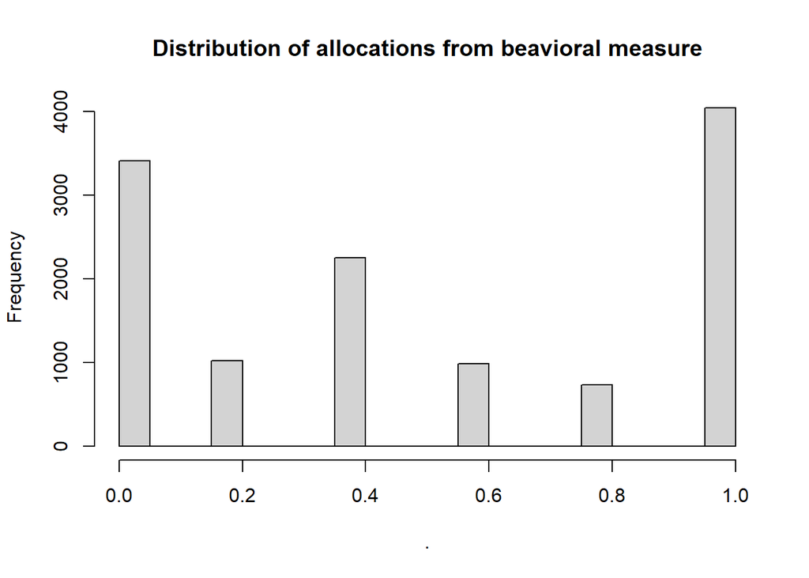

```r
#r, child = "2_main_results.Rmd", eval = TRUE}
# put in separate files later

df_2$solidarity_bahaviour %>% hist(main = "Distribution of allocations from beavioral measure")
```

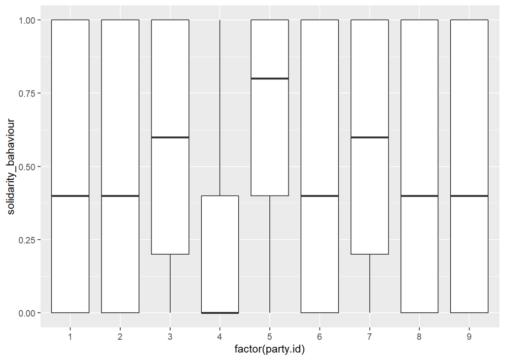

```r
df_2 %>%
  ggplot(aes(factor(party.id), solidarity_bahaviour )) + geom_boxplot()
```

```r
  ggtitle("Distribution of allocations from beavioral measure")
```

$title [1] “Distribution of allocations from beavioral measure”

attr(,“class”) [1] “labels”

```r
df_2$party.id
```